# Genómica y medicina de precisión en cáncer de mama #8235 Gº Ingeniería de la Salud

Rosa Isabel Ciudad Garcia** *rcg1022@alu.ubu.es* // **Maroua Zaroual Houbbi** *mzh1001@alu.ubu.es* // **Maryam El Haouzi** *mex1057@alu.ubu.es* //

“5º Semestre / 3º Curso 2026-2027”

# 1. Introducción

## 1.1. Contexto y motivación

El **cáncer de mama es la neoplasia maligna** más frecuente en mujeres a nivel mundial, pero lejos de constituir una única entidad clínica, engloba un conjunto altamente heterogéneo de tumores con comportamientos biológicos, pronósticos y respuestas terapéuticas muy dispares. Tradicionalmente, su abordaje clínico se basaba en criterios histopatológicos y en la expresión inmunohistoquímica de receptores hormonales (estrógenos y progesterona) y del receptor HER2. Sin embargo, los avances en genómica funcional han permitido establecer clasificaciones moleculares intrínsecas —como el panel PAM50—, que dividen estos tumores en subtipos bien diferenciados:**Luminal A, Luminal B, HER2-enriquecido, Basal-like y Normal-like.**

Comprender qué determina la **agresividad diferencial** de estos subtipos es un **pilar fundamental de la medicina de precisión**. Mientras que los tumores luminales suelen presentar un crecimiento más lento y responden favorablemente a terapias endocrinas, subtipos como el Basal-like (estrechamente ligado al fenotipo triple negativo) o el **HER2-enriquecido** muestran una elevada tasa proliferativa, mayor inestabilidad cromosómica, microambientes tumorales más hipóxicos y un peor pronóstico clínico, careciendo además en muchos casos de dianas hormonales convencionales. Por ello, integrar información molecular de gran escala con datos clínicos, pautas terapéuticas reales y contexto demográfico y epidemiológico resulta esencial para caracterizar la agresividad tumoral y evaluar cómo se traslada el perfil genómico a la práctica clínica.

## 1.2. Pregunta de investigación

¿Cómo varían los **marcadores de agresividad tumoral** —inestabilidad genómica (FGA), carga mutacional (TMB) e hipoxia— y las **pautas terapéuticas** administradas entre los distintos subtipos moleculares PAM50 del cáncer de mama, y qué influencia ejercen las **disparidades raciales** y el contexto epidemiológico d**e obesidad** en su presentación clínica?

## 1.3. Objetivos

- **Objetivo general:** Caracterizar la agresividad biológica, el perfil clínico y el abordaje terapéutico de los distintos subtipos moleculares del cáncer de mama en la cohorte **TCGA-BRCA**, mediante la integración y análisis reproducible en R de fuentes genómicas, clínicas y epidemiológicas.
- **Objetivos específicos:**
  1. **Integrar y armonizar** datos moleculares de **cBioPortal**, registros clínicos y terapéuticos del **NCI Genomic Data Commons (GDC)** y datos epidemiológicos de la **Organización Mundial de la Salud (OMS)** en un único conjunto de datos relacional.
  2. **Comparar la agresividad molecular y el pronóstico** entre subtipos intrínsecos (*Luminal A*, *Luminal B*, *HER2-enriquecido*, *Basal-like* y *Normal-like*) a partir de la fracción del genoma alterado (`FGA`), la carga mutacional no sinónima (`TMB`), la puntuación de hipoxia de Buffa, la edad al diagnóstico y la supervivencia global.
  3. **Evaluar la aplicación de la medicina de precisión y los determinantes poblacionales**, analizando la distribución de modalidades terapéuticas por subtipo molecular, las posibles disparidades raciales en el estadio clínico al diagnóstico y el contexto mundial de prevalencia de obesidad femenina.

# 2. Metodología y fuentes de datos

## 2.1. Fuentes de datos

Para la integración de datos de este seminario se ha combinado una estrategia híbrida de extracción programática mediante APIs oficiales y carga de ficheros locales, garantizando tanto la actualización de los datos como la reproducibilidad del flujo de trabajo en R.

### 2.1.1. Importación de las fuentes

#### Importación de datos clínicos y genómicos desde cBioPortal

```r
# Instalación de paquete
#install.packages("cbioportalR")

# Libreria especifica
library(cbioportalR)
# 1. Conectar a la base pública (no requiere token)
set_cbioportal_db("public")

# 2. Descargar datos clínicos de pacientes y muestras del estudio TCGA-BRCA
cbio_raw <- get_clinical_by_study(study_id = "brca_tcga_pan_can_atlas_2018") %>%
  select(patientId, clinicalAttributeId, value) %>%
  distinct() %>%
  pivot_wider(names_from = clinicalAttributeId, values_from = value)
names(cbio_raw)
```

```
##  [1] "patientId"
##  [2] "AGE"
##  [3] "AJCC_PATHOLOGIC_TUMOR_STAGE"
##  [4] "AJCC_STAGING_EDITION"
##  [5] "BUFFA_HYPOXIA_SCORE"
##  [6] "CANCER_TYPE_ACRONYM"
##  [7] "DAYS_LAST_FOLLOWUP"
##  [8] "DAYS_TO_BIRTH"
##  [9] "DAYS_TO_INITIAL_PATHOLOGIC_DIAGNOSIS"
## [10] "DFS_MONTHS"
## [11] "DFS_STATUS"
## [12] "DSS_MONTHS"
## [13] "DSS_STATUS"
## [14] "ETHNICITY"
## [15] "FORM_COMPLETION_DATE"
```

[output cut: 44 more lines]

#### Importación de datos clínicos, tratamientos y seguimientos desde NCI GDC

```r
#Instalación del paquete(una unica ejecucion)->descomentar si es la primera vez que renderiza el documento
#if (!require("BiocManager", quietly = TRUE)) {
#  install.packages("BiocManager")
#}
#BiocManager::install("GenomicDataCommons")

#Importacion
library(GenomicDataCommons)

# 1. Construimos y ejecutamos la consulta al endpoint de casos (pacientes)
gdc_resultados <- cases() %>%
  filter(~ project.project_id == "TCGA-BRCA") %>%
  expand(c("demographic", "diagnoses", "diagnoses.treatments", "follow_ups")) %>%
  results_all()
# 2. Convertimos la respuesta en un tibble/data.frame manejable
gdc_raw <- as_tibble(gdc_resultados)

# Verificamos cuántos pacientes (filas) y bloques de variables hemos descargado
dim(gdc_raw)
```

```
## [1] 1098   27
```

```r
names(gdc_raw)
```

```
##  [1] "id"                      "slide_ids"
##  [3] "submitter_slide_ids"     "disease_type"
##  [5] "analyte_ids"             "submitter_id"
##  [7] "submitter_analyte_ids"   "aliquot_ids"
##  [9] "submitter_aliquot_ids"   "created_datetime"
## [11] "sample_ids"              "submitter_sample_ids"
## [13] "primary_site"            "updated_datetime"
## [15] "case_id"                 "state"
## [17] "portion_ids"             "submitter_portion_ids"
## [19] "lost_to_followup"        "diagnosis_ids"
## [21] "follow_ups"              "days_to_consent"
## [23] "diagnoses"               "consent_type"
## [25] "demographic"             "submitter_diagnosis_ids"
## [27] "index_date"
```

Por el contrario, para los datos epidemiológicos de prevalencia de obesidad de la **Organización Mundial de la Salud (OMS)**, se ha optado exclusivamente por la descarga e importación local del fichero oficial en formato .csv mediante el paquete readr. Esta decisión metodológica se debe a que **la OMS no dispone de un cliente API específico en R** dentro de las herramientas trabajadas en la asignatura, y el intento de lectura directa desde la **URL web del portal generaba errores de importación** y formato en los campos; por ello, el almacenamiento local asegura la integridad estructural de la tabla y evita fallos de compilación en el documento.

```r
oms_raw <- read_csv(file = "INPUT/DATA/obesidad_oms.csv", show_col_types = FALSE)
```

```r
# Resumen de dimensiones para comprobar que todo se ha cargado
cat("cBioPortal :", nrow(cbio_raw), "filas x", ncol(cbio_raw), "columnas\n")
```

```
## cBioPortal : 1084 filas x 59 columnas
```

```r
cat("GDC JSON   :", nrow(gdc_raw),  "filas x", ncol(gdc_raw),  "columnas\n")
```

```
## GDC JSON   : 1098 filas x 27 columnas
```

```r
cat("OMS CSV    :", nrow(oms_raw),  "filas x", ncol(oms_raw),  "columnas\n")
```

```
## OMS CSV    : 26865 filas x 34 columnas
```

```r
# Verificación rápida de columnas clave
cat("Columnas cBioPortal:", paste(names(cbio_raw)[1:5], collapse = ", "), "...\n")
```

```
## Columnas cBioPortal: patientId, AGE, AJCC_PATHOLOGIC_TUMOR_STAGE, AJCC_STAGING_EDITION, BUFFA_HYPOXIA_SCORE ...
```

```r
cat("Columnas GDC:", paste(names(gdc_raw)[1:5], collapse = ", "), "...\n")
```

```
## Columnas GDC: id, slide_ids, submitter_slide_ids, disease_type, analyte_ids ...
```

```r
cat("Columnas OMS:", paste(names(oms_raw)[1:5], collapse = ", "), "...\n")
```

```
## Columnas OMS: IndicatorCode, Indicator, ValueType, ParentLocationCode, ParentLocation ...
```

## 2.2. Flujo de análisis

El trabajo se ha organizado en varios pasos, desde la descarga de los datos hasta la obtención de los resultados:

1. **Importación de los datos.** Se descargan los datos clínicos y moleculares de cBioPortal y los datos clínicos y de tratamientos del GDC a través de sus APIs, y los datos de obesidad de la OMS desde un fichero CSV.
2. **Limpieza.** Se pasa la tabla de cBioPortal de formato largo a formato ancho, se filtran los datos de la OMS (solo mujeres y el último año disponible) y se seleccionan las variables que nos interesan.
3. **Desanidado del JSON del GDC.** Se aplanan los bloques anidados (datos demográficos, diagnósticos y tratamientos) para tener una fila por paciente.
4. **Cruce de las fuentes.** Se unen los datos de cBioPortal y del GDC por el identificador de la paciente y después se añaden los datos de la OMS por país.
5. **Análisis descriptivo.** Se crean tablas resumen por subtipo PAM50, por raza y por tratamiento.
6. **Visualización.** Se hacen gráficos para comparar la inestabilidad genómica, los tratamientos, el estadio al diagnóstico, la carga mutacional y la obesidad.
7. **Interpretación.** Por último, se comentan los resultados para responder a la pregunta de investigación.

# 3. Procesamiento y limpieza

En esta sección se van a transformar los datos de tal manera que estos puedan ser utilizados para la **generación de tablas y gráficas que nos ayudarán a responder las preguntas planteadas** en la introducción del seminario. Se va a realizar la limpieza del fichero procedente de cBioPortal, así como de los datos proporcionados por la OMS. Además, se llevará a cabo el desanidado del JSON procedente del GDC para poder cruzar los conjuntos de datos mencionados.

## 3.1. Limpieza de cBioPortal

La API de cBioPortal devuelve los datos con identificadores en inglés. Estos datos pueden **contener registros a nivel de muestra y no a nivel de paciente**, dificultando la unión con otras tablas.

Para poder analizarlos y cruzarlos fácilmente, necesitamos **reorganizar la tabla** de manera que cada fila corresponda a un único paciente y cada columna a uno de sus datos.

```r
cbio_wide <- cbio_raw %>%
  as_tibble() %>%
  transmute(
    patientId = str_sub(patientId, 1, 12),
    subtipo = SUBTYPE,
    edad = as.numeric(AGE),
    raza = RACE,
    sexo = SEX,
    estado_vital= OS_STATUS,
    supervivencia_meses = as.numeric(OS_MONTHS),
    radioterapia  = RADIATION_THERAPY,
    hipoxia_tumor= as.numeric(BUFFA_HYPOXIA_SCORE),
    tmb = as.numeric(TMB_NONSYNONYMOUS),
    inestabilidad_genomica =as.numeric(FRACTION_GENOME_ALTERED),
    codigo_pais = "USA"
  )

str(cbio_wide)
```

```
## tibble [1,084 × 12] (S3: tbl_df/tbl/data.frame)
##  $ patientId             : chr [1:1084] "TCGA-3C-AAAU" "TCGA-3C-AALI" "TCGA-3C-AALJ" "TCGA-3C-AALK" ...
##  $ subtipo               : chr [1:1084] "BRCA_LumA" "BRCA_Her2" "BRCA_LumB" "BRCA_LumA" ...
##  $ edad                  : num [1:1084] 55 50 62 52 50 42 52 70 59 56 ...
##  $ raza                  : chr [1:1084] "White" "Black or African American" "Black or African American" "Black or African American" ...
##  $ sexo                  : chr [1:1084] "Female" "Female" "Female" "Female" ...
##  $ estado_vital          : chr [1:1084] "0:LIVING" "0:LIVING" "0:LIVING" "0:LIVING" ...
##  $ supervivencia_meses   : num [1:1084] 133.1 131.7 48.5 47.6 11.4 ...
##  $ radioterapia          : chr [1:1084] "No" "Yes" "No" "No" ...
##  $ hipoxia_tumor         : num [1:1084] -21 5 -5 -27 -27 -25 -13 -35 -35 -29 ...
##  $ tmb                   : num [1:1084] 0.8 15.267 0.933 1.5 0.7 ...
##  $ inestabilidad_genomica: num [1:1084] 0.7787 0.7164 0.534 0.0764 0.2364 ...
##  $ codigo_pais           : chr [1:1084] "USA" "USA" "USA" "USA" ...
```

Para solucionar este problema, hemos convertido a tibble la tabla original. Después, tomamos los 12 primeros caracteres del ID del paciente y renombramos las variables para facilitar el entendimiento del conjunto de datos. Finalmente, hemos añadido una columna donde todos los registros tienen el valor USA con el fin de poder cruzar los datos georgráficos más adelante.

## 3.2. Limpieza de la OMS

Ahora, debemos realizar la limpieza de los datos de obesidad proporcionados por la Organización Mundial de la Salud. Para ello, se han filtrado los datos para utilizar únicamente los **procedentes de mujeres** ya que el cáncer de mama es una enfermedad mayoritariamente femenina y la inclusión de datos procedentes de hombres podría perjudicar el posterior análisis estadístico ya que la incidencia en ellos es casi nula. Además se van a trabajar únicamente los **datos generados en el último año disponible**.

```r
oms_obesidad <- oms_raw %>%
  dplyr::filter(
    Dim1ValueCode == "SEX_FMLE",
    Period == max(Period, na.rm = TRUE)
  ) %>%
  dplyr::select( cod_pais= SpatialDimValueCode, pais = Location, ano  = Period, porcentaje_obesas = FactValueNumeric)

str(oms_obesidad)
```

```
## tibble [199 × 4] (S3: tbl_df/tbl/data.frame)
##  $ cod_pais         : chr [1:199] "NPL" "MMR" "IND" "BFA" ...
##  $ pais             : chr [1:199] "Nepal" "Myanmar" "India" "Burkina Faso" ...
##  $ ano              : num [1:199] 2024 2024 2024 2024 2024 ...
##  $ porcentaje_obesas: num [1:199] 10.3 10.4 10.4 10.7 11.6 ...
```

Además, se han seleccionado para el análisis exclusivamente 4 columnas que se han considerado relevantes para este. A estos atributos se les ha cambiado el nombre para facilitar la comprensión de los datos.

## 3.3. Desanidado del JSON del GDC

El último paso antes de realizar el cruce de los datos es **aplanar y consolidar la estructura anidada del último de los JSON**. Para llevarlo a cabo y obtener una única fila por paciente se han seguido una serie de pasos:

- Se ha normalizado el identificador del paciente. Además, se han seleccionado primary_site, disease_type y se han desplagado en columnas los atributos anidados de demographic mediante unnest_wider().
- Se ha llevado a cabo la consolidación de los de diagnósticos y tratamientos; para ello se han desanidado las listas diagnoses y diagnoses_treatments con unnest(). A continuación, se han agrupado por patientId para extraer el primer estadio patológico disponible (estadio_gdc) y concatenado en una única cadena todos los tratamientos únicos recibidos por cada paciente (tratamientos).
- Por último, se han combinado ambas tablas mediante left_join() usando patientId como clave, obteniendo una tabla que podemos integrar con el resto de fuentes.

**Importante:** `unnest_wider()` despliega los datos demográficos en nuevas columnas, mientras que `unnest()` expande en varias filas los diagnósticos y tratamientos de cada paciente.

```r
library(tidyverse)

# 1. Tabla exterior: ID del paciente y datos demográficos
gdc_pacientes <- gdc_raw %>%
  mutate(patientId = str_sub(submitter_id, 1, 12)) %>%
  dplyr::select(patientId, primary_site, disease_type, demographic) %>%
  unnest_wider(demographic, names_sep = ".")

# 2. Tabla interior: diagnósticos y tratamientos
gdc_tratamientos <- gdc_raw %>%
  mutate(patientId = str_sub(submitter_id, 1, 12)) %>%
  dplyr::select(patientId, diagnoses) %>%
  unnest(diagnoses, keep_empty = TRUE, names_sep = "_") %>%
  dplyr::select(patientId, any_of(c("diagnoses_ajcc_pathologic_stage", "diagnoses_tumor_stage", "diagnoses_treatments"))) %>%
  unnest(diagnoses_treatments, keep_empty = TRUE, names_sep = "_") %>%
  group_by(patientId) %>%
  summarise(
    estadio_gdc  = first(na.omit(diagnoses_ajcc_pathologic_stage)),
    tratamientos = paste(unique(na.omit(diagnoses_treatments_treatment_type)), collapse = "; "),
    .groups = "drop"
  )

# 3. unimos 1 a 1 con left_join()
gdc_limpio <- gdc_pacientes %>%
  left_join(gdc_tratamientos, by = "patientId")

str(gdc_limpio)
```

```
## tibble [1,098 × 21] (S3: tbl_df/tbl/data.frame)
##  $ patientId                                     : chr [1:1098] "TCGA-BH-A0B2" "TCGA-A8-A08S" "TCGA-A8-A09C" "TCGA-BH-A1F5" ...
##  $ primary_site                                  : chr [1:1098] "Breast" "Breast" "Breast" "Breast" ...
##  $ disease_type                                  : chr [1:1098] "Ductal and Lobular Neoplasms" "Ductal and Lobular Neoplasms" "Ductal and Lobular Neoplasms" "Ductal and Lobular Neoplasms" ...
##  $ demographic.race                              : chr [1:1098] NA "not reported" "not reported" "white" ...
##  $ demographic.ethnicity                         : chr [1:1098] NA "not reported" "not reported" "not hispanic or latino" ...
##  $ demographic.vital_status                      : chr [1:1098] NA "Alive" "Alive" "Dead" ...
##  $ demographic.age_at_index                      : int [1:1098] NA 71 69 62 56 47 61 81 73 63 ...
##  $ demographic.submitter_id                      : chr [1:1098] NA "TCGA-A8-A08S_demographic" "TCGA-A8-A09C_demographic" "TCGA-BH-A1F5_demographic" ...
##  $ demographic.days_to_birth                     : int [1:1098] NA -25994 -25355 -22842 -20482 -17346 -22373 -29858 -26724 -23294 ...
##  $ demographic.created_datetime                  : logi [1:1098] NA NA NA NA NA NA ...
##  $ demographic.year_of_birth                     : int [1:1098] NA NA NA NA NA NA NA NA NA 1946 ...
##  $ demographic.demographic_id                    : chr [1:1098] NA "833dad58-d5d6-5d30-96b0-6ba696d5a033" "a696eb4e-6327-5623-8c68-8b71b336c866" "e7090c21-d3bb-57df-9763-7b1017d0ccf3" ...
##  $ demographic.updated_datetime                  : chr [1:1098] NA "2025-12-06T10:15:48.290081-06:00" "2025-12-06T11:09:28.273131-06:00" "2025-12-06T11:24:03.995640-06:00" ...
##  $ demographic.age_is_obfuscated                 : logi [1:1098] NA FALSE FALSE FALSE FALSE FALSE ...
##  $ demographic.state                             : chr [1:1098] NA "released" "released" "released" ...
##  $ demographic.sex_at_birth                      : chr [1:1098] NA "female" "female" "female" ...
##  $ demographic.year_of_death                     : logi [1:1098] NA NA NA NA NA NA ...
##  $ demographic.country_of_residence_at_enrollment: chr [1:1098] NA "Germany" "Germany" NA ...
##  $ demographic.days_to_death                     : int [1:1098] NA NA NA 2712 723 NA NA NA NA NA ...
##  $ estadio_gdc                                   : chr [1:1098] NA "Stage IIA" "Stage X" "Stage IIA" ...
##  $ tratamientos                                  : chr [1:1098] "" "Pharmaceutical Therapy, NOS; Radiation Therapy, NOS; Hormone Therapy; Radiation, External Beam; Surgery, NOS" "Surgery, NOS; Pharmaceutical Therapy, NOS; Radiation Therapy, NOS" "Surgery, NOS" ...
```

## 3.4. Cruce de las tres fuentes

Por último, vamos a **cruzar los datos** con el objetivo de poder generar visualizaciones y tablas que nos permitan efectuar un análisis crítico de los datasets encontrados. En este apartado se van a cruzar los datos procedentes de las tres fuentes. Para ello, hemos estandarizado la variable geográfica del GDC (`demographic.country_of_residence_at_enrollment`), transformando el nombre de cada país a su código internacional ISO-3.

A continuación, hemos realizado un **cruce a nivel de paciente** entre las relaciones procedentes de cBioPortal y GDC mediante un `inner_join()` utilizando el identificador `patientId`. Hemos incorporado, además, los **datos de obesidad** procedentes de la OMS mediante un `left_join()`

```r
# 1. Mapeamos el país de residencia del GDC a código ISO-3 para cruzar con la OMS
gdc_para_cruce <- gdc_limpio %>%
  mutate(
    cod_pais = case_when(
      demographic.country_of_residence_at_enrollment == "United States" ~ "USA",
      demographic.country_of_residence_at_enrollment == "Germany" ~ "DEU",
      demographic.country_of_residence_at_enrollment == "Russia" ~ "RUS",
      demographic.country_of_residence_at_enrollment == "Vietnam" ~ "VNM",
      demographic.country_of_residence_at_enrollment == "Poland" ~ "POL",
      demographic.country_of_residence_at_enrollment == "Ukraine" ~ "UKR",
      demographic.country_of_residence_at_enrollment == "Brazil"~ "BRA",
      demographic.country_of_residence_at_enrollment == "Canada" ~ "CAN",
      TRUE ~ "USA"))

# 2. Cruce de las 3 fuentes: inner_join (cBioPortal + GDC) y left_join (OMS)
datos_cruzados <- cbio_wide %>%
  inner_join(gdc_para_cruce, by = "patientId") %>%
  left_join(oms_obesidad, by = "cod_pais") %>%
  dplyr::filter(!is.na(subtipo)) %>%
  mutate(
    Subtipo = case_when(
      subtipo == "BRCA_LumA" ~ "Luminal A",
      subtipo == "BRCA_LumB" ~ "Luminal B",
      subtipo == "BRCA_Basal" ~ "Basal-like",
      subtipo == "BRCA_Her2"~ "HER2-enriquecido",
      TRUE ~ "Normal-like"),
  tiene_tratamiento_gdc = ifelse(tratamientos == "", "Sin registro", "Con registro")
)

str(datos_cruzados)
```

```
## tibble [981 × 38] (S3: tbl_df/tbl/data.frame)
##  $ patientId                                     : chr [1:981] "TCGA-3C-AAAU" "TCGA-3C-AALI" "TCGA-3C-AALJ" "TCGA-3C-AALK" ...
##  $ subtipo                                       : chr [1:981] "BRCA_LumA" "BRCA_Her2" "BRCA_LumB" "BRCA_LumA" ...
##  $ edad                                          : num [1:981] 55 50 62 52 50 42 52 70 59 56 ...
##  $ raza                                          : chr [1:981] "White" "Black or African American" "Black or African American" "Black or African American" ...
##  $ sexo                                          : chr [1:981] "Female" "Female" "Female" "Female" ...
##  $ estado_vital                                  : chr [1:981] "0:LIVING" "0:LIVING" "0:LIVING" "0:LIVING" ...
##  $ supervivencia_meses                           : num [1:981] 133.1 131.7 48.5 47.6 11.4 ...
##  $ radioterapia                                  : chr [1:981] "No" "Yes" "No" "No" ...
##  $ hipoxia_tumor                                 : num [1:981] -21 5 -5 -27 -27 -25 -13 -35 -35 -29 ...
##  $ tmb                                           : num [1:981] 0.8 15.267 0.933 1.5 0.7 ...
##  $ inestabilidad_genomica                        : num [1:981] 0.7787 0.7164 0.534 0.0764 0.2364 ...
##  $ codigo_pais                                   : chr [1:981] "USA" "USA" "USA" "USA" ...
##  $ primary_site                                  : chr [1:981] "Breast" "Breast" "Breast" "Breast" ...
##  $ disease_type                                  : chr [1:981] "Ductal and Lobular Neoplasms" "Ductal and Lobular Neoplasms" "Ductal and Lobular Neoplasms" "Ductal and Lobular Neoplasms" ...
```

[output cut: 24 more lines]

Tras la unión de las 3 fuentes hemos aplicado un **filtrado** para conservar exclusivamente las muestras que disponen de una clasificación molecular válida, es decir, aquellas que presentan un subtipo válido. Posteriormente, se han recodificado las etiquetas de dichos subtipos para darles un nombre más fácil de entender.

Por último, se ha generado una variable `tiene_tratamiento_gdc` que permite identificar qué pacientes cuentan con **información terapeútica** registrada en la base de datos de GDC.

# 4. Resultados

## 4.1. Análisis descriptivo

Se van a realizar una serie de tablas que resumen la información facilitando el análisis crítico de la información proporcionada por los datos.

### Tabla 1: Tabla por subtipo molecular PAM50.

Hemos construido una tabla que presenta ciertas estadísticas relativas a los diferentes subtipos de cáncer de mama. Para ello, hemos asegurado que ciertos datos se almacenen de **forma númerica** para poder operar matemáticamente con ellos. Después, hemos dividido el conjunto de datos en los 5 grupos correspondientes a los subtipos PAM50 con `group_by()`y por último, hemos **calculado y presentado las estadísticas** deseadas.

```r
tabla_subtipos <- datos_cruzados %>%
  mutate(
    edad                = as.numeric(edad),
    supervivencia_meses = as.numeric(supervivencia_meses),
    hipoxia_tumor       = as.numeric(hipoxia_tumor)
  ) %>%
  group_by(Subtipo) %>%
  summarise(
    Num_pacientes   = length(patientId),
    Porcentaje    = round(length(patientId) / length(datos_cruzados$patientId) * 100, 2),
    Edad_media    = round(mean(edad, na.rm = TRUE), 2),
    Edad_dt       = round(sd(edad, na.rm = TRUE), 2),
    Superv_meses  = round(mean(supervivencia_meses, na.rm = TRUE), 2),
    Hipoxia_media = round(mean(hipoxia_tumor, na.rm = TRUE), 2)
  ) %>%
  arrange(desc(Num_pacientes))

tabla_subtipos
```

| Subtipo | Num_pacientes | Porcentaje | Edad_media | Edad_dt | Superv_meses | Hipoxia_media |
| --- | --- | --- | --- | --- | --- | --- |
| Luminal A | 499 | 50.87 | 59.34 | 13.53 | 42.91 | -22.96 |
| Luminal B | 197 | 20.08 | 58.69 | 13.06 | 36.85 | -5.58 |
| Basal-like | 171 | 17.43 | 55.52 | 12.50 | 44.08 | 17.78 |
| HER2-enriquecido | 78 | 7.95 | 58.19 | 13.05 | 36.07 | 8.62 |
| Normal-like | 36 | 3.67 | 55.06 | 12.07 | 43.70 | -15.00 |

En la tabla anterior podemos observar un claro **predominio del subtipo Luminal A**, seguido del subtipo Luminal B, ambos positivos para los receptores de estrógeno y progesterona. Los siguientes subtipos más comunes son Basal-like, que se corresponde con un triple negativo y HER2-Enriquecido, positivo pata el receptor HER2. El subtipo menos común es el normal-like que se caracteriza por mostrar patrones expresión génica similares a los del tejido mamario normal.

Por último, el **índice de hipoxia tumoral** es variable y depende del subtipo.

### Tabla 2: Distribución de subtipos por raza

En esta segunda relación se pretende presentar la **distribución de los subtipos trabajados previamente por raza**. Para ello, hemos realizado un filtrado con objeto de seleccionar los cuatro grupos raciales definidos en el registro.

Despés de esto, hemos agrupado por raza y subtipo utilizando la función `group_by()`. De esta manera, hemos podido contabilizar el número de pacientes y ordenado ,finalmente, los resultados por raza y número de pacientes en orden descendiente. Además, también se ha generado un atributo que calcula cuánto pocentaje del total de casos dentro de la raza suponen los casos de ese subtipo.

```r
tabla_razas <- datos_cruzados %>%
  dplyr::filter(
    raza == "White" |
    raza == "Black or African American" |
    raza == "Asian" |
    raza == "American Indian or Alaska Native"
  ) %>%
  group_by(raza, Subtipo) %>%
  summarise(
    Num_pacientes = length(patientId)
  ) %>%
   mutate(
    Proporcion = round(Num_pacientes / sum(Num_pacientes) * 100, 2)
  )%>%
  arrange(raza, desc(Num_pacientes))

tabla_razas
```

| raza | Subtipo | Num_pacientes | Proporcion |
| --- | --- | --- | --- |
| American Indian or Alaska Native | HER2-enriquecido | 1 | 100.00 |
| Asian | Luminal A | 20 | 33.90 |
| Asian | Luminal B | 16 | 27.12 |
| Asian | HER2-enriquecido | 15 | 25.42 |
| Asian | Basal-like | 7 | 11.86 |
| Asian | Normal-like | 1 | 1.69 |
| Black or African American | Luminal A | 56 | 35.22 |
| Black or African American | Basal-like | 53 | 33.33 |
| Black or African American | Luminal B | 26 | 16.35 |
| Black or African American | HER2-enriquecido | 15 | 9.43 |

[output cut: 6 more lines]

La representación racial dentro del estudio es dispar, siendo mucho más alto el número de pacientes blancas y casi nula la representación de indios americanos o nativos de Alaska. Al observar la distribución interna de cada grupo, destaca el hecho de que mientras en las pacientes blancas el subtipo Luminal A supera ampliamente al resto, en las pacientes negras o afroamericanas el subtipo Basal-like toma un peso relativo mucho mayor, igualándose prácticamente este, al peso del subtipo más común. Esto último refleja ciertas **disparidades raciales** en cuanto al desarrollo de cáncer de mama y los diferentes subtipos de este.

### Tabla 3: Clínica gdc

Por último, se ha construido una tabla que refleja el **número de pacientes de cada subtipo que ha recibido radioterapia**. Para ello, se han agrupado los datos por subtipo y se ha presentado una relación en la que se han calculado el número de pacientes que lo presentan, así como el número de estos que han recibido un tratamiento de radioterapia y cuánto suponen estos pacientes en porcentaje.

```r
tabla_clinica_gdc <- datos_cruzados %>%
  group_by(Subtipo) %>%
  summarise(
    Num_pacientes = length(patientId),
    Con_radioterapia = sum(radioterapia == "Yes", na.rm = TRUE),
    Porcentaje = round(Con_radioterapia / Num_pacientes * 100, 2)
  ) %>%
  arrange(desc(Num_pacientes))

tabla_clinica_gdc
```

| Subtipo | Num_pacientes | Con_radioterapia | Porcentaje |
| --- | --- | --- | --- |
| Luminal A | 499 | 253 | 50.70 |
| Luminal B | 197 | 98 | 49.75 |
| Basal-like | 171 | 89 | 52.05 |
| HER2-enriquecido | 78 | 33 | 42.31 |
| Normal-like | 36 | 17 | 47.22 |

Vemos que aproximadamente en todos los subtipos el **porcentaje de pacientes que reciben radioterapia es similar**, en torno al 50%, siendo algo más bajo el porcentaje en el subtipo HER2-enriquecido. Esto puede deberse, por un lado, a la presencia de valores ausentes y a que muchas pacientes son sometidas a una mastectomía total en estadios tempranos, cuando no hay ganglios afectados.Muchas veces estos casos no requieren radioterapia, lo que hace caer el porcentaje de mujeres que lo reciben.

## 4.2. Inestabilidad genómica por subtipo

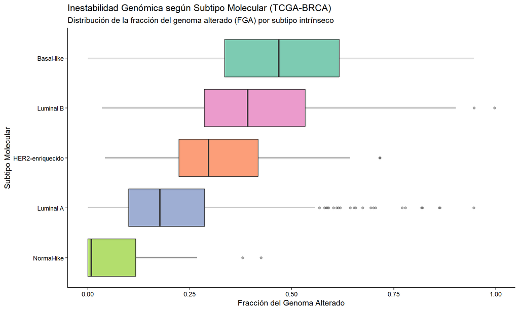

```r
p1_inestabilidad <- datos_cruzados %>%
  dplyr::filter(!is.na(Subtipo), !is.na(inestabilidad_genomica)) %>%
  ggplot(aes(x = reorder(Subtipo, inestabilidad_genomica, FUN = median),
             y = inestabilidad_genomica,
             fill = Subtipo)) +
  geom_boxplot(alpha = 0.85, outlier.alpha = 0.4) +
  coord_flip() +
  scale_fill_brewer(palette = "Set2") +
  labs(title = "Inestabilidad Genómica según Subtipo Molecular (TCGA-BRCA)",
    subtitle = "Distribución de la fracción del genoma alterado (FGA) por subtipo intrínseco",
    x = "Subtipo Molecular",
    y = "Fracción del Genoma Alterado"
  ) +
  theme_classic() +
  theme(legend.position = "none")

p1_inestabilidad
```

Se observa un gradiente claro de inestabilidad cromosómica (Fracción del Genoma Alterado, `FGA`) que confirma la agresividad diferencial de cada subtipo. **Basal-like** presenta la mayor mediana de alteración genómica (~0,47) y el rango intercuartílico más desplazado hacia valores altos, seguido de **Luminal B** (~0,39) y **HER2-enriquecido** (~0,30). En el extremo opuesto, **Luminal A** (~0,18) y **Normal-like** (~0,01) muestran genomas mucho más estables, lo que concuerda con su crecimiento más lento y mejor pronóstico clínico, aunque *Luminal A* exhibe numerosos valores atípicos (*outliers*) de pacientes con alta inestabilidad que podrían comportarse de forma más agresiva.

## 4.3. Medicina de precisión en acción: tratamientos por subtipo

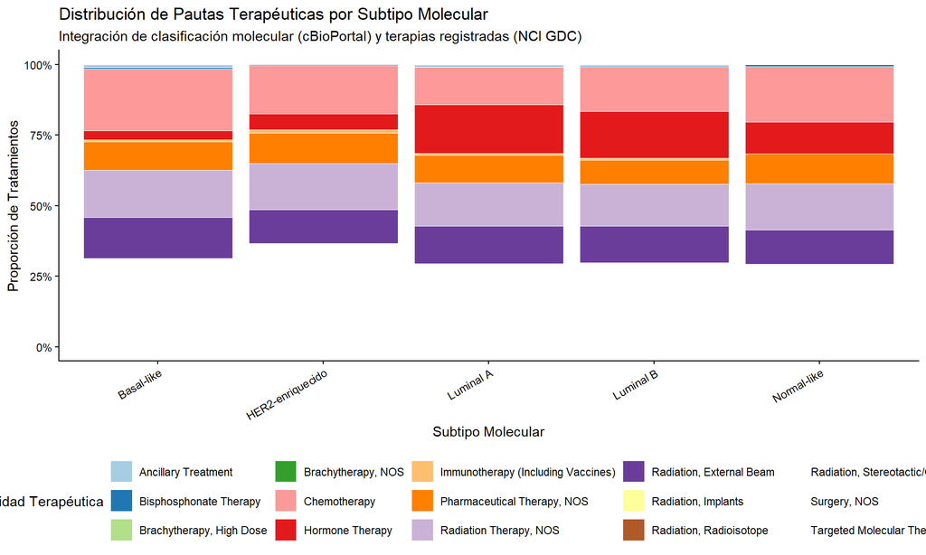

```r
p2_tratamientos <- datos_cruzados %>%
  dplyr::filter(!is.na(Subtipo), tratamientos != "") %>%
  separate_rows(tratamientos, sep = "; ") %>%
  dplyr::count(Subtipo, tratamientos) %>%
  ggplot(aes(x = Subtipo, y = n, fill = tratamientos)) +
  geom_col(position = "fill", colour = "white", linewidth = 0.2) +
  scale_y_continuous(labels = scales::percent) +
  scale_fill_brewer(palette = "Paired") +
  labs(title = "Distribución de Pautas Terapéuticas por Subtipo Molecular",
    subtitle = "Integración de clasificación molecular (cBioPortal) y terapias registradas (NCI GDC)",
    x = "Subtipo Molecular",
    y = "Proporción de Tratamientos",
    fill = "Modalidad Terapéutica"
  ) +
  theme_classic() +
  theme(axis.text.x = element_text(angle = 30, hjust = 1),
        legend.position = "bottom")

p2_tratamientos
```

La gráfica refleja cómo la biología del tumor guía la decisión clínica dentro de la medicina de precisión. En **Luminal A** y **Luminal B**, la **terapia hormonal** ocupa una proporción muy destacada al tratarse de tumores dependientes de receptores de estrógenos y progesterona. Por el contrario, en **Basal-like** la terapia hormonal es prácticamente inexistente y predominan la **quimioterapia citotóxica** y la radioterapia externa, ya que al carecer de dianas hormonales y sobreexpresión de HER2 estas pacientes no son candidatas a terapias endocrinas convencionales.

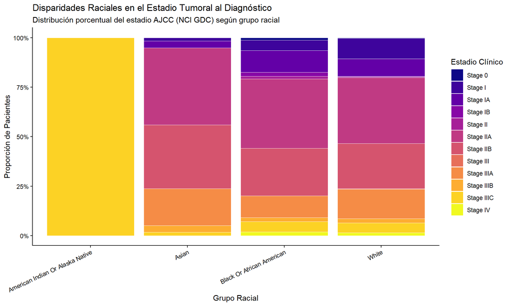

```r
p3_disparidades <- datos_cruzados %>%
  dplyr::filter(
    !is.na(demographic.race),
    !demographic.race %in% c("not reported", "Unknown", "Not Available"),
    !is.na(estadio_gdc),
    estadio_gdc != "Stage X"
  ) %>%
  ggplot(aes(x = str_to_title(demographic.race), fill = estadio_gdc)) +
  geom_bar(position = "fill", colour = "white", linewidth = 0.2) +
  scale_y_continuous(labels = scales::percent) +
  scale_fill_viridis_d(option = "plasma") +
  labs(title = "Disparidades Raciales en el Estadio Tumoral al Diagnóstico",
    subtitle = "Distribución porcentual del estadio AJCC (NCI GDC) según grupo racial",
    x  = "Grupo Racial",
    y = "Proporción de Pacientes",
    fill = "Estadio Clínico"
  ) + theme_classic() + theme(axis.text.x = element_text(angle = 25, hjust = 1))

p3_disparidades
```

## 4.5. Edad, TMB y estado vital

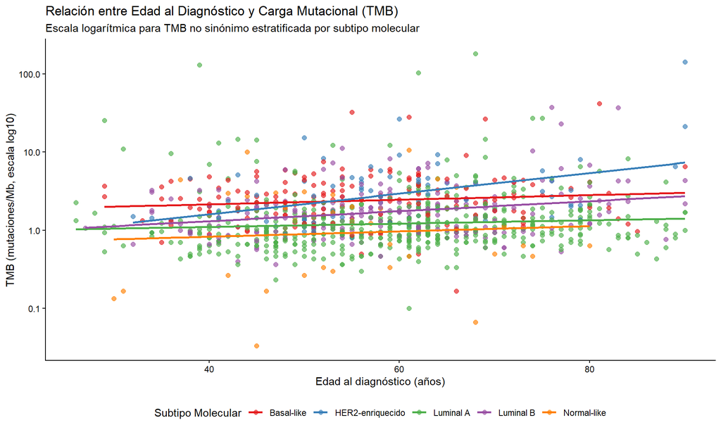

```r
p4_edad_tmb <- datos_cruzados %>%
  dplyr::filter(!is.na(edad), !is.na(tmb), !is.na(Subtipo), tmb > 0) %>%
  ggplot(aes(x = edad, y = tmb, colour = Subtipo)) +
  geom_point(alpha = 0.65, size = 2) +
  geom_smooth(method = "lm", se = FALSE, linewidth = 0.9) +
  scale_y_log10() +
  scale_colour_brewer(palette = "Set1") +
  labs(title = "Relación entre Edad al Diagnóstico y Carga Mutacional (TMB)",
    subtitle = "Escala logarítmica para TMB no sinónimo estratificada por subtipo molecular",
    x = "Edad al diagnóstico (años)",
    y  = "TMB (mutaciones/Mb, escala log10)",
    colour = "Subtipo Molecular"
  ) +
  theme_classic() +
  theme(legend.position = "bottom")

p4_edad_tmb
```

La escala logarítmica del `TMB` muestra una pendiente ligeramente ascendente con la edad en todos los subtipos. Esto es debido a la acumulación progresiva de mutaciones somáticas a lo largo de la vida, siendo especialmente pronunciada en el subtipo **HER2-enriquecido**, que alcanza los valores más altos en pacientes de edad avanzada. Asimismo, los subtipos más agresivos (**Basal-like** y **HER2-enriquecido**) se sitúan sistemáticamente por encima de **Luminal A** y **Normal-like** en prácticamente todo el rango de edad, confirmando una mayor tasa mutacional basal. Por ello, edades mas avanzadas requieren revisiones periodicas para prevenir.

## 4.6. Contexto mundial: obesidad femenina y subtipos

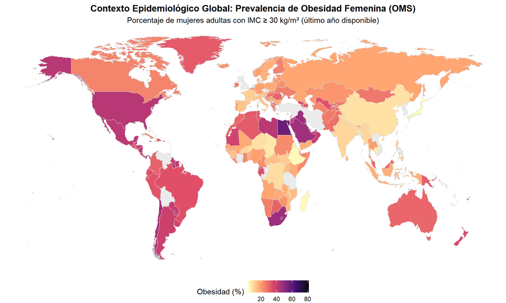

```r
mapa_mundo <- map_data("world") %>%
  as_tibble() %>%
  dplyr::filter(region != "Antarctica") %>%
  mutate(
    # Armonizamos nombres clave para cruzar con la tabla 'oms_obesidad'
    pais_clave = case_when(
      region == "USA" ~ "United States of America",
      region == "Russia" ~ "Russian Federation",
      region == "UK" ~ "United Kingdom",
      TRUE ~ region))

# Unimos el mapa con los datos de la OMS
mapa_oms <- mapa_mundo %>%
  left_join(oms_obesidad, by = c("pais_clave" = "pais"))

p5_mapa <- ggplot(mapa_oms, aes(x = long, y = lat, group = group)) +
  geom_polygon(aes(fill = porcentaje_obesas), colour = "grey85", linewidth = 0.15) +
  scale_fill_viridis_c(option = "magma", direction = -1, na.value = "grey92") +
  coord_fixed(1.3) +
  labs(
    title = "Contexto Epidemiológico Global: Prevalencia de Obesidad Femenina (OMS)",
    subtitle = "Porcentaje de mujeres adultas con IMC ≥ 30 kg/m² (último año disponible)",
    fill= "Obesidad (%)") +
  theme_void() + theme(legend.position = "bottom", plot.title = element_text(face = "bold", hjust = 0.5),
    plot.subtitle = element_text(hjust = 0.5))

p5_mapa
```

El mapamundi elaborado con los datos más recientes de la OMS evidencia una marcada heterogeneidad geográfica en la prevalencia de obesidad femenina adulta ($\text{IMC} \ge 30\text{ kg/m}^2$). Mientras que países de Asia Oriental (como Japón o China) y gran parte de África subsahariana registran tasas inferiores al 10–15 % (tonos amarillo claro), regiones como **Norteamérica —destacando Estados Unidos con cifras superiores al 40 %—, Oriente Medio, el norte de África (especialmente Egipto) y el cono sur americano** presentan las prevalencias más elevadas del planeta (tonos magenta y púrpura oscuro). Desde el punto de vista oncológico, la obesidad constituye un factor de riesgo consolidado para el desarrollo y progresión del cáncer de mama (especialmente en mujeres posmenopáusicas con tumores receptores hormonales positivos, como *Luminal A* y *Luminal B*), debido al aumento de la aromatización periférica de estrógenos en el tejido adiposo, la resistencia a la insulina y un estado de inflamación crónica de bajo grado. Dado que la inmensa mayoría de las pacientes incluidas en la cohorte **TCGA-BRCA** proceden de instituciones clínicas estadounidenses (tal como se observa al cruzar con la variable de país de residencia del GDC), este mapa permite contextualizar el entorno poblacional de alto riesgo metabólico en el que se origina la muestra estudiada. No obstante, al integrar un indicador agregado a nivel nacional con datos clínicos individuales, es imprescindible cautela metodológica para no incurrir en una **falacia ecológica**, ya que una elevada prevalencia poblacional en el país de origen no permite inferir el índice de masa corporal individual de cada paciente analizada.

# 5. Discusión

## 5.1. Interpretación de los hallazgos

En el caso de la inestabilidad genómica (FGA), Basal-like tiene los valores más altos, seguido de Luminal B y HER2-enriquecido, mientras que Luminal A y Normal-like tienen genomas mucho más estables. Con la hipoxia pasa algo parecido: Basal-like tiene la puntuación media más alta (17,78) y Luminal A la más baja (-22,96). La carga mutacional (TMB) también es mayor en Basal-like y HER2-enriquecido. Esto coincide con lo que se describe en la bibliografía, donde los subtipos Basal-like y HER2-enriquecido se consideran los más agresivos y Luminal A el de mejor pronóstico (Perou et al., 2000; Cancer Genome Atlas Network, 2012).

En cuanto a los tratamientos, vemos que la biología del tumor influye en la decisión clínica. Las pacientes con tumores luminales reciben con frecuencia terapia hormonal, porque sus tumores dependen de los estrógenos. En cambio, en Basal-like la terapia hormonal casi no aparece y predominan la quimioterapia y la radioterapia. Esto es un ejemplo claro de medicina de precisión: el tratamiento se elige según las características moleculares del tumor.

Por último, el mapa de la OMS muestra que Estados Unidos, de donde proceden la mayoría de las pacientes de TCGA-BRCA, tiene una de las prevalencias de obesidad femenina más altas del mundo. La obesidad es un factor de riesgo de cáncer de mama en mujeres posmenopáusicas (Lauby-Secretan et al., 2016). Sin embargo, como se trata de un dato a nivel de país, solo sirve como contexto y no se puede relacionar directamente con cada paciente.

## 5.2. Limitaciones

- **Sesgo ecológico:** datos agregados a nivel poblacional (OMS) → falacia ecológica.
- **Variables de confusión no incluidas:** acceso a cribado, estadio al diagnóstico, factores socioeconómicos.
- **Categorización racial:** categorías administrativas que agrupan poblaciones heterogéneas.
- **Datos de tratamiento:** registro retrospectivo, posible infranotificación.

## 5.3. Conclusiones

Integrando datos de cBioPortal, el GDC y la OMS hemos podido caracterizar los subtipos de cáncer de mama de la cohorte TCGA-BRCA. Los resultados confirman que Basal-like y HER2-enriquecido son los subtipos más agresivos a nivel genómico, y que el tratamiento se adapta al subtipo molecular. Además, el cruce de fuentes nos ha permitido ver la influencia de factores como la raza o el contexto de obesidad, algo que no se podría estudiar con una sola base de datos.

# 7. Referencias

- Buffa, F. M., Harris, A. L., West, C. M., & Miller, C. J. (2010). Large meta-analysis of multiple cancers reveals a common, compact and highly prognostic hypoxia metagene. *British Journal of Cancer, 102*(2), 428–435. https://doi.org/10.1038/sj.bjc.6605450
- Cancer Genome Atlas Network. (2012). Comprehensive molecular portraits of human breast tumours. *Nature, 490*(7418), 61–70. https://doi.org/10.1038/nature11412
- Carey, L. A., Perou, C. M., Livasy, C. A., Dressler, L. G., Cowan, D., Conway, K., … & Millikan, R. C. (2006). Race, breast cancer subtypes, and survival in the Carolina Breast Cancer Study. *JAMA, 295*(21), 2492–2502. https://doi.org/10.1001/jama.295.21.2492
- Cerami, E., Gao, J., Dogrusoz, U., Gross, B. E., Sumer, S. O., Aksoy, B. A., … & Schultz, N. (2012). The cBio cancer genomics portal: An open platform for exploring multidimensional cancer genomics data. *Cancer Discovery, 2*(5), 401–404. https://doi.org/10.1158/2159-8290.CD-12-0095
- Gao, J., Aksoy, B. A., Dogrusoz, U., Dresdner, G., Gross, B., Sumer, S. O., … & Schultz, N. (2013). Integrative analysis of complex cancer genomics and clinical profiles using the cBioPortal. *Science Signaling, 6*(269), pl1. https://doi.org/10.1126/scisignal.2004088
- Grossman, R. L., Heath, A. P., Ferretti, V., Varmus, H. E., Lowy, D. R., Kibbe, W. A., & Staudt, L. M. (2016). Toward a shared vision for cancer genomic data. *New England Journal of Medicine, 375*(12), 1109–1112. https://doi.org/10.1056/NEJMp1607591
- Hoadley, K. A., Yau, C., Hinoue, T., Wolf, D. M., Lazar, A. J., Drill, E., … & Laird, P. W. (2018). Cell-of-origin patterns dominate the molecular classification of 10,000 tumors from 33 types of cancer. *Cell, 173*(2), 291–304. https://doi.org/10.1016/j.cell.2018.03.022
- Lauby-Secretan, B., Scoccianti, C., Loomis, D., Grosse, Y., Bianchini, F., & Straif, K. (2016). Body fatness and cancer: Viewpoint of the IARC Working Group. *New England Journal of Medicine, 375*(8), 794–798. https://doi.org/10.1056/NEJMsr1606602
- NCD Risk Factor Collaboration (NCD-RisC). (2024). Worldwide trends in underweight and obesity from 1990 to 2022: A pooled analysis of 3663 population-representative studies with 222 million children, adolescents, and adults. *The Lancet, 403*(10431), 1027–1050. https://doi.org/10.1016/S0140-6736(23)02750-2
- Parker, J. S., Mullins, M., Cheang, M. C. U., Leung, S., Voduc, D., Vickery, T., … & Bernard, P. S. (2009). Supervised risk predictor of breast cancer based on intrinsic subtypes. *Journal of Clinical Oncology, 27*(8), 1160–1167. https://doi.org/10.1200/JCO.2008.18.1370
- Perou, C. M., Sørlie, T., Eisen, M. B., van de Rijn, M., Jeffrey, S. S., Rees, C. A., … & Botstein, D. (2000). Molecular portraits of human breast tumours. *Nature, 406*(6797), 747–752. https://doi.org/10.1038/35021093
- National Cancer Institute. (s.f.). *GDC Data Portal: TCGA-BRCA*. https://portal.gdc.cancer.gov/projects/TCGA-BRCA
- Organización Mundial de la Salud. (s.f.). *Obesity among adults, BMI ≥ 30, prevalence (age-standardized estimate) (%)*. Global Health Observatory. https://www.who.int/data/gho
- R Core Team. (2025). *R: A language and environment for statistical computing*. R Foundation for Statistical Computing. https://www.R-project.org/